# onsetsynch

Tuomas Eerola

2018-01-14

This is a simple package meant to facilitate the analysis of onset data. Made in the context of Interpersonal Entrainment Music Performance (IEMP).

## Example

We will first read in data which consists of extracted onsets (done with MIR toolbox for Matlab) and hand annotated labelling of beats and structures. This is a Cuban song, recorded by Adrian Poole (more details here).

### Read data

```r
asere <- read.csv(url('https://raw.githubusercontent.com/tuomaseerola/onsetsynch/master/data/Asere_OU_2.csv'))
head(asere)
```

```
##    Piece N Label.SD Beat.pos SD.pos SD Clave_. Section Virtual.SD
## 1 Song_2 7    01:01        1      1  1       Y     Son   5.037333
## 2 Song_2 7    01:02        1      2  2       N     Son   5.260063
## 3 Song_2 7    01:03        1      3  3       N     Son   5.482792
## 4 Song_2 7    01:04        1      4  4       Y     Son   5.705521
## 5 Song_2 7    01:05        2      1  5       N     Son   5.928250
## 6 Song_2 7    01:06        2      2  6       N     Son   6.150979
##      Tactus    Tempo Clave     Bass   Guitar     Tres    Bongo Bell
## 1 0.8909167 67.34637    NA       NA       NA       NA       NA   NA
## 2 0.8909167 67.34637    NA       NA 5.281932       NA       NA   NA
## 3 0.8909167 67.34637    NA       NA 5.480643       NA 5.477695   NA
## 4 0.8909167 67.34637    NA 5.714555 5.707537 5.730943 5.718635   NA
## 5 0.8909167 67.34637    NA 5.927078 5.939071 5.917083 5.926234   NA
## 6 0.8909167 67.34637    NA       NA 6.153243 6.144901 6.155149   NA
##   Cl_Dens Bs_Dens Gt_Dens Tr_Dens Bn_Dens Bl_Dens
## 1      NA      NA      NA      NA      NA      NA
## 2      NA      NA      NA      NA      NA      NA
## 3      NA      NA      NA      NA     2.0      NA
## 4      NA      NA      NA      NA     2.0      NA
## 5      NA      NA      NA      NA     2.5      NA
## 6      NA      NA      NA      NA     2.5      NA
```

There is quite a bit of extra data here, which we won’t need. I also want to handle the data in `tidyverse` fashion and give few diagnostics about the data.

```r
library(dplyr)
library(ggplot2)
library(reshape2)
```

```r
asere <- as_tibble(asere)
asere <- select(asere,SD,Section,Tempo,SD,Virtual.SD,Clave,Bass,Guitar,Tres,Bongo,Bell) # keep only key variables
print(dim(asere))
```

```
## [1] 1585   10
```

```r
round(colSums(!is.na(asere[,which(colnames(asere)=="Clave"):which(colnames(asere)=="Bell")]),na.rm = T)/nrow(asere),2) # percentage of available data
```

```
##  Clave   Bass Guitar   Tres  Bongo   Bell
##   0.31   0.31   0.89   0.58   0.40   0.25
```

### Load `onsetsynch` library

OK. Load up the library and visualise the relative asynchrony to equal division for each instrument.

```r
devtools::install_github("tuomaseerola/onsetsynch") # install the developmental package synchrony
```

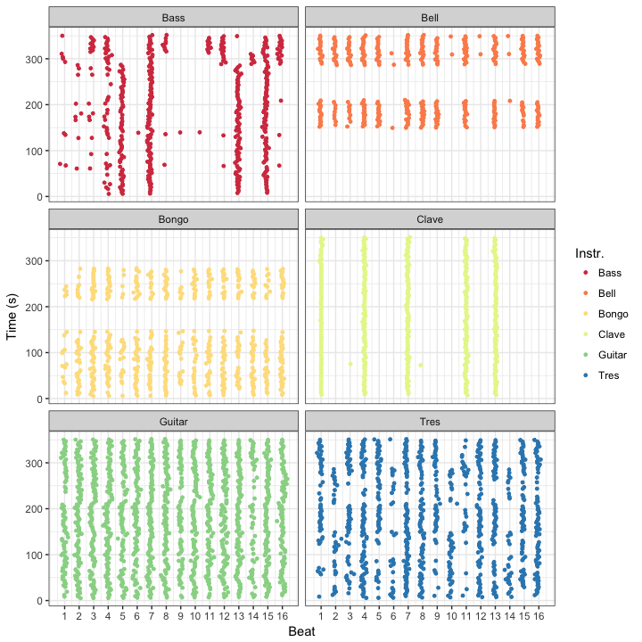

```r
library(onsetsynch)
p <- onsetsynch_by_beat_plot(asere,c('Bass','Clave','Guitar','Tres','Bongo','Bell'),'SD','Virtual.SD',pcols=2)
print(p)
```

### Calculate the synchrony between the instruments

How well are the pairs of instruments synced? Since the instrument play different amounts of onset, and these are bound to at different beats, the mutual amount of onsets for each pair varies. In order to keep the mean and standard deviations comparable, we will randomnly sample the joint onsets for both instruments.

```r
set.seed(1201) # set random seed before doing any sampling in order replicate results
N <- 100 # Let's select 100 onsets
d1 <- onsetsynch_sample_paired(asere,'Clave','Bass',N,1,'SD',TRUE) # Determine the instrument pair
```

```
## [1] "onsets in common: 241"
```

```r
print(paste('Asynchrony mean=',round(mean(d1$asynch*1000),4),'ms & sd. dev=',round(sd(d1$asynch*1000),3)))
```

```
## [1] "Asynchrony mean= 18.0883 ms & sd. dev= 21.525"
```

The first example might still be in accurate since we now know that there are at least 241 shared onset times between the Clave and the Bass. Let’s redo the random sampling 10 times so we get more observations whilst still always sampling 100 joint onsets.

```r
d10 <- onsetsynch_sample_paired(asere,'Clave','Bass',N,10,'SD',TRUE) # New parameter 10 for 10 times
```

```
## [1] "onsets in common: 241"
```

```r
print(paste('Asynchrony mean=',round(mean(d10$asynch*1000),4),'ms & sd. dev=',round(sd(d10$asynch*1000),3)))
```

```
## [1] "Asynchrony mean= 16.9891 ms & sd. dev= 19.692"
```

Carry this out for all possible pairings of the instruments and visualise the results.

```r
inst<-c('Clave','Bass','Guitar','Tres','Bongo','Bell') # Define instrument for exhaustive pairwise comparison
dn <- onsetsynch_execute_pairs(asere,inst,N,10,'SD')
```

```
## [1] "onsets in common: 241"
## [1] "onsets in common: 462"
## [1] "onsets in common: 312"
## [1] "onsets in common: 189"
## [1] "onsets in common: 173"
## [1] "onsets in common: 469"
## [1] "onsets in common: 354"
## [1] "onsets in common: 166"
## [1] "onsets in common: 173"
## [1] "onsets in common: 858"
## [1] "onsets in common: 575"
## [1] "onsets in common: 397"
## [1] "onsets in common: 344"
## [1] "onsets in common: 348"
## [1] "onsets in common: 0"
```

```r
dim(dn$asynch)
```

```
## [1] 1000   15
```

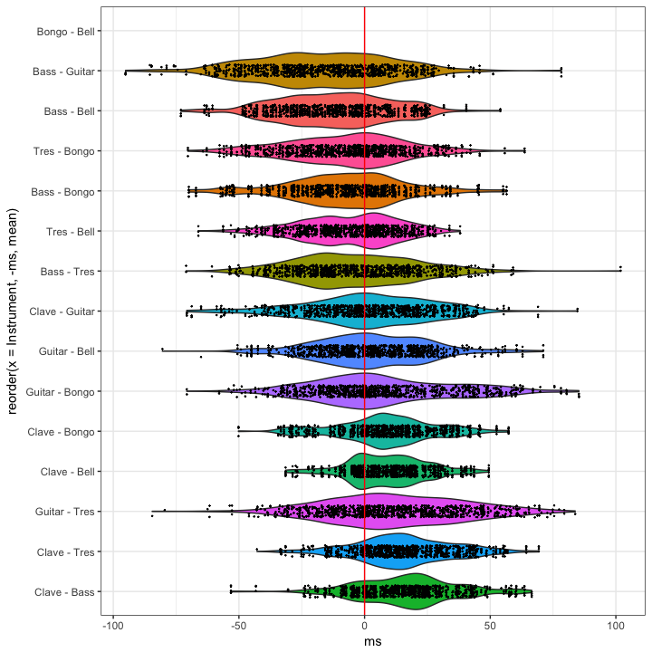

```r
p2 <- onsetsynch_by_pair_plot(dn)  # plot
print(p2)
```

```r
# Compare only three interesting instruments in terms of the synchrony across the beats
inst<-c('Bass','Guitar','Tres') # Define instrument for exhaustive pairwise comparison
dn <- onsetsynch_execute_pairs(asere,inst,N,10,'SD')
```

```
## [1] "onsets in common: 469"
## [1] "onsets in common: 354"
## [1] "onsets in common: 858"
```

```r
p3 <- onsetsynch_by_pair_plot(dn,bybeat=TRUE) # plot by beats
```

```
## 'data.frame':    3000 obs. of  3 variables:
##  $ Instrument: Factor w/ 3 levels "Bass - Guitar",..: 1 1 1 1 1 1 1 1 1 1 ...
##  $ ms        : num  -51.7 -40.2 -75.3 -27.7 -18.4 ...
##  $ beatL     : int  13 14 7 2 15 5 4 13 7 7 ...
```

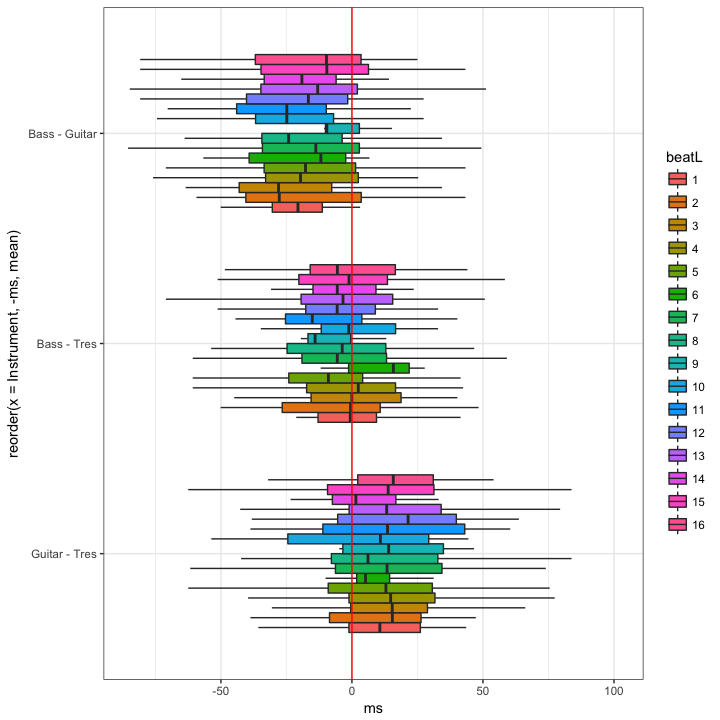

```r
print(p3)
```

Calculate simple t-statistics for the instrument pairs.

```r
T <- data.frame(onsetsynch_by_pair_stats(dn))
print(T)
```

```
##         tval         pval
## 1 -20.236730 1.394008e-76
## 2  -4.494225 7.798707e-06
## 3  14.534338 1.467087e-43
```

### Other visualisations

Visualise asynchronies against another variable, for instance, tempo.

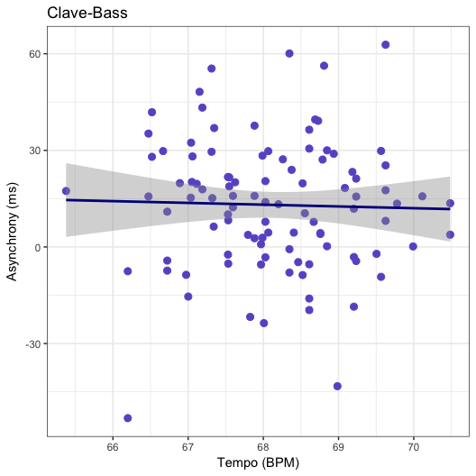

```r
d1 <- onsetsynch_sample_paired(asere,'Clave','Bass',200,1,'Tempo')
g1 <- onsetsynch_by_X_plot(d1,meta = 'Clave-Bass',xlab='Tempo (BPM)')
print(g1)
```